# Final Project - Classification Models and Cluster Identification

> The banknote dataset, part of the R package mclust, contains six measurements taken from 100 genuine and 100 counterfeit Swiss 1000-franc bills.  
> - Status: genuine (true), counterfeit (false)  
> - Length: length of the banknote (mm)  
> - Left: width of the left margin (mm)  
> - Right: width of the right margin (mm)  
> - Bottom: width of the bottom margin (mm)  
> - Top: width of the top margin (mm)  
> - Diagonal: diagonal length (mm)  
> The researchers aim to determine whether a clustering method based on these measurements can detect the status of the banknotes, i.e., determine their authenticity. The following steps are requested to achieve this goal.

# Steps

## 1. Generate a data frame with the problem’s data and transform the variable status into a factor.

```r
library(mclust)

Bills <- as.data.frame(banknote)

#Status ya es un factor.

str(Bills)
```

```
## 'data.frame':    200 obs. of  7 variables:
##  $ Status  : Factor w/ 2 levels "counterfeit",..: 2 2 2 2 2 2 2 2 2 2 ...
##  $ Length  : num  215 215 215 215 215 ...
##  $ Left    : num  131 130 130 130 130 ...
##  $ Right   : num  131 130 130 130 130 ...
##  $ Bottom  : num  9 8.1 8.7 7.5 10.4 9 7.9 7.2 8.2 9.2 ...
##  $ Top     : num  9.7 9.5 9.6 10.4 7.7 10.1 9.6 10.7 11 10 ...
##  $ Diagonal: num  141 142 142 142 142 ...
```

## 2. Generate a data frame that excludes the status variable. This data frame will be used for analysis.

```r
Bills_2 <- Bills[,-c(1)]

str(Bills_2)
```

```
## 'data.frame':    200 obs. of  6 variables:
##  $ Length  : num  215 215 215 215 215 ...
##  $ Left    : num  131 130 130 130 130 ...
##  $ Right   : num  131 130 130 130 130 ...
##  $ Bottom  : num  9 8.1 8.7 7.5 10.4 9 7.9 7.2 8.2 9.2 ...
##  $ Top     : num  9.7 9.5 9.6 10.4 7.7 10.1 9.6 10.7 11 10 ...
##  $ Diagonal: num  141 142 142 142 142 ...
```

## 3. Generate a data frame with the standardized variables.

```r
Bills_Std <- scale(Bills_2, center = TRUE, scale = TRUE)
```

## 4. Determine whether the available data table supports clustering (use the Hopkins statistic and the graphical method). Comment.

```r
library(clustertend)
set.seed(222)
hopkins(Bills_Std, n = nrow(Bills_Std) - 1)
```

```
## $H
## [1] 0.2675401
```

> The results provide evidence that the observations in the dataset **Bills_Std** do not follow a completely uniform spatial distribution. Some form of grouping in the data is suggested, although it doesn’t appear very clear.

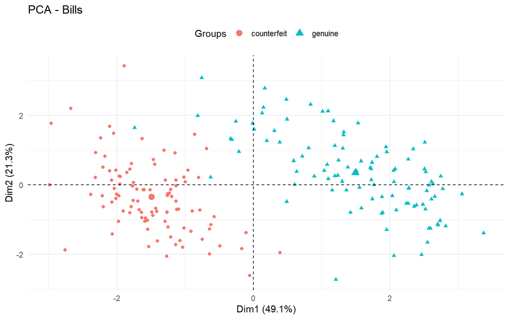

```r
library(factoextra)
library(ggpubr)

pca_Bills_std <- prcomp(Bills_Std)
Graf1 <- fviz_pca_ind(X= pca_Bills_std, habillage = Bills$Status, geom = "point", title = "PCA - Bills", pallete = "jco")+
  theme_minimal() + theme(legend.position = "top")
Graf1
```

> The graph shows that there might be two distinct groups: one formed by the genuine bills (centered on the right side of the graph) and another formed by the counterfeit bills (centered on the left side of the graph).

## 5. Evaluate the number of clusters that the problem supports (use Elbow, Silhouette, Gap, and Dendrogram methods). Explicitly state the conclusions.

### Elbow method

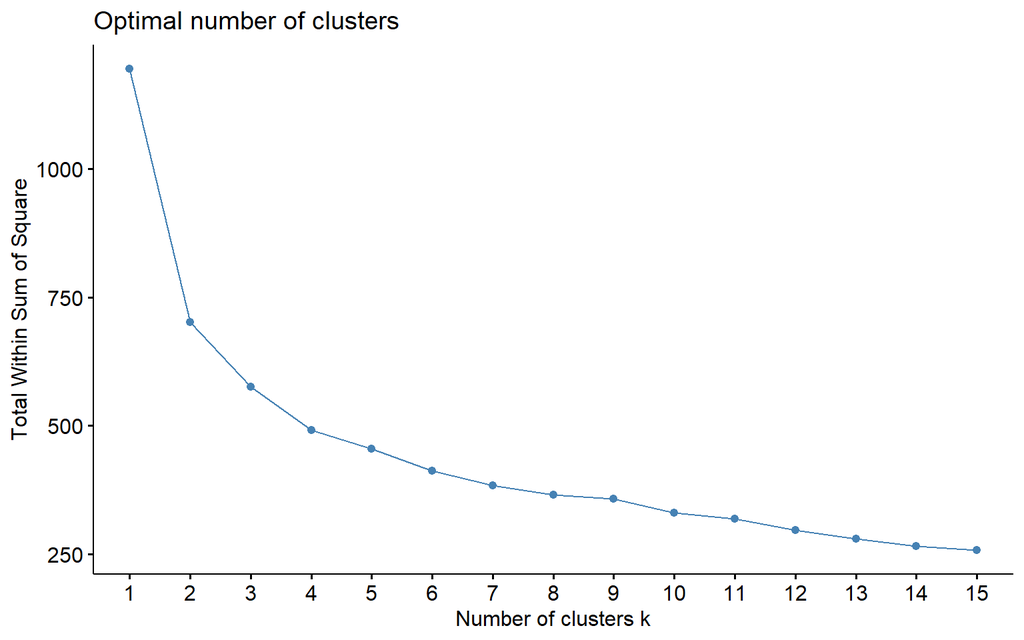

```r
fviz_nbclust(x = Bills_Std, FUNcluster = kmeans, method = "wss", k.max = 15) +
  labs(title = "Optimal number of clusters")
```

### Silhouette method

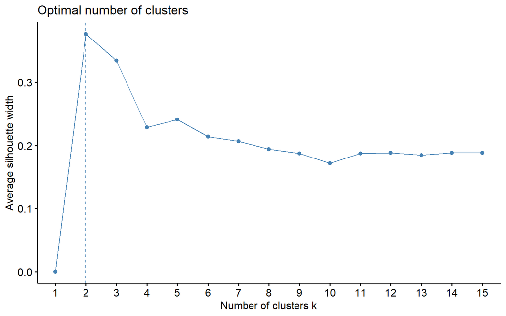

```r
fviz_nbclust(x = Bills_Std, FUNcluster = kmeans, method = "silhouette", k.max = 15) +
  labs(title = "Optimal number of clusters")
```

### GAP method

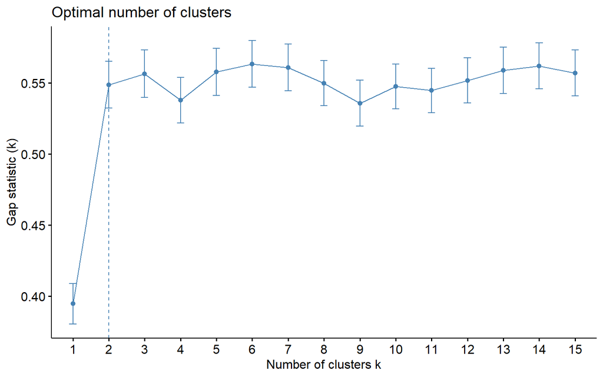

```r
fviz_nbclust(x = Bills_Std, FUNcluster = kmeans, method = "gap_stat", k.max = 15, nboot = 500, verbose = FALSE) +
  labs(title = "Optimal number of clusters")
```

### Dendrogram

```r
mat_dist <- dist(x = Bills_Std, method = "euclidean")

hc_euclidea_complete <- hclust(d = mat_dist, method = "complete")
cor(x = mat_dist, cophenetic(hc_euclidea_complete))
```

```
## [1] 0.6740081
```

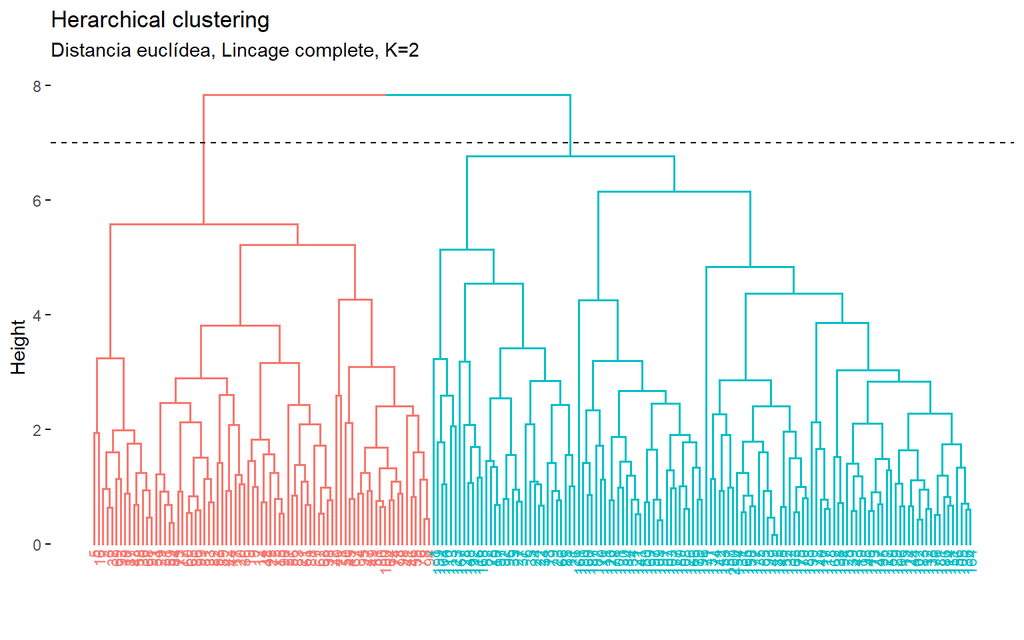

```r
fviz_dend(x = hc_euclidea_complete, k = 2, cex = 0.6) +
  geom_hline(yintercept = 7, linetype = "dashed") +
  labs(title = "Herarchical clustering",
       subtitle = "Distancia euclídea, Lincage complete, K=2")
```

> Using the Elbow, Silhouette, and GAP methods, a break in the curve can be observed at 2 clusters. Beyond this point, the curve plateaus. For the Elbow method, this means that the increase in total intra-cluster variance is no longer substantial. For the Silhouette method, it indicates that the maximum measure of the silhouette coefficient for all observations has been reached. Finally, for the GAP method, it means that a cluster structure most distinct from a random uniform distribution has been achieved.  
> On the other hand, the dendrogram allows us to see how the unions were formed. In this graph, the clearest separation can be observed at a height of 7, where two groups or clusters are represented.

## 6. Using the k-means method, classify the observations into two groups.

```r
set.seed(102)
km_clusters <- kmeans(x = Bills_Std, centers = 2, nstart = 50)
km_clusters
```

```
## K-means clustering with 2 clusters of sizes 108, 92
##
## Cluster means:
##       Length       Left      Right     Bottom        Top   Diagonal
## 1 -0.1221604  0.5482838  0.6163644  0.6788357  0.5494346 -0.8005001
## 2  0.1434057 -0.6436375 -0.7235582 -0.7968941 -0.6449884  0.9397176
##
## Clustering vector:
##   [1] 1 2 2 2 2 1 2 2 2 1 1 2 2 2 2 2 2 2 2 2 2 2 2 2 2 2 2 2 2 2 2 2 2 2 2 2 2
##  [38] 2 2 2 2 2 2 2 2 2 2 2 2 2 2 2 2 2 2 2 2 2 2 2 2 2 2 2 2 1 2 2 2 1 2 2 2 2
##  [75] 2 2 2 2 2 2 2 2 2 2 1 2 2 2 2 2 2 2 2 2 2 2 1 2 2 2 1 1 1 1 1 1 1 1 1 1 1
## [112] 1 1 1 1 1 1 1 1 1 1 1 1 1 1 1 1 1 1 1 1 1 1 1 1 1 1 1 1 1 1 1 1 1 1 1 1 1
## [149] 1 1 1 1 1 1 1 1 1 1 1 1 1 1 1 1 1 1 1 1 1 1 1 1 1 1 1 1 1 1 1 1 1 1 1 1 1
## [186] 1 1 1 1 1 1 1 1 1 1 1 1 1 1 1
##
## Within cluster sum of squares by cluster:
## [1] 396.3549 304.8505
##  (between_SS / total_SS =  41.3 %)
##
## Available components:
##
## [1] "cluster"      "centers"      "totss"        "withinss"     "tot.withinss"
## [6] "betweenss"    "size"         "iter"         "ifault"
```

## 7. Assign a group classification to each observation.

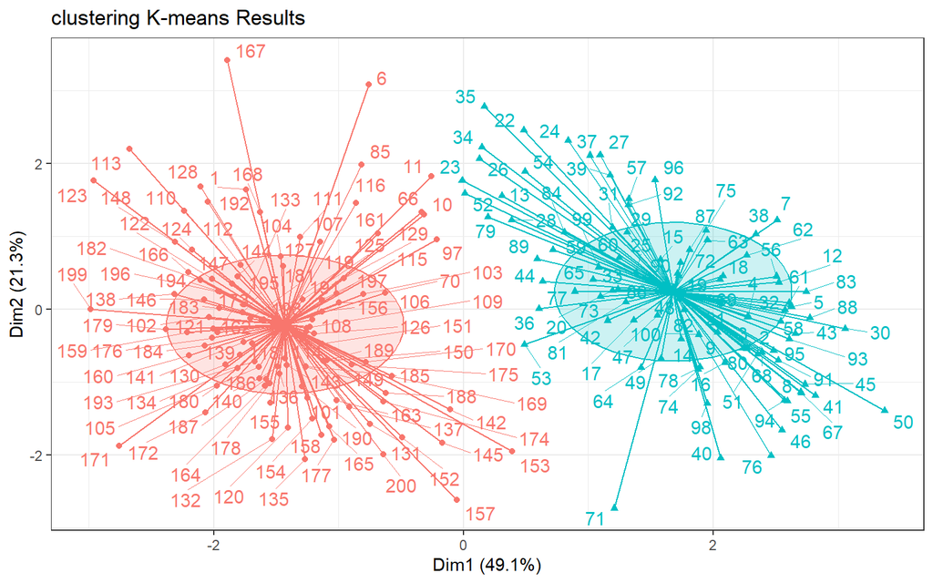

```r
library(tidyverse)
Bills <- Bills %>%
  mutate(cluster = as.factor(km_clusters$cluster))

fviz_cluster(object = km_clusters, data = Bills_Std, show.clust.cent = TRUE,
             ellipse.type = "euclid", star.plot = TRUE, repel = TRUE) +
  labs(title = "clustering K-means Results") +
  theme_bw() +
  theme(legend.position = "none")
```

## 8. Compare the group membership with status and determine the percentage of correctly classified banknotes. What conclusions can be drawn?

```r
Bills %>%
  filter(Status == "genuine") %>%
  count(cluster)
```

```
##   cluster  n
## 1       1  8
## 2       2 92
```

```r
Bills %>%
  filter(Status == "counterfeit") %>%
  count(cluster)
```

```
##   cluster   n
## 1       1 100
```

```r
192/200
```

```
## [1] 0.96
```

> 100% of the counterfeit banknotes were correctly classified. 92% of the genuine banknotes were correctly classified. In total, 96% of the banknotes were classified correctly. This indicates that the variables length, left margin width, right margin width, top margin width, bottom margin width, and diagonal length are effective for detecting the authenticity of a banknote.

# Final Report

> To determine whether the dimensions of the bills allow identifying whether the specimens are genuine or counterfeit, a clustering method was used to estimate the number of identified clusters and then compare the assignments with the status variable (authenticity or falsity of the bills).  
> The variables used for cluster creation were:  
> - Length: length of the banknote (mm)  
> - Left: width of the left margin (mm)  
> - Right: width of the right margin (mm)  
> - Bottom: width of the bottom margin (mm)  
> - Top: width of the top margin (mm)  
> - Diagonal: diagonal length (mm)  
> It began by determining whether there was evidence that the observations formed clusters. This was evidenced by obtaining a Hopkins index of 0.26.  
> Next, the optimal number of clusters was sought by comparing three methods: the Elbow method, the Silhouette method, and the GAP method. In all three cases, a solution of two groups was obtained. Additionally, a dendrogram was created for graphical representation.  
> Once the number of groups was chosen, the observations were classified using the k-means method.  
> Finally, the group to which each bill was assigned was compared with the status variable to determine the percentage of bills that had been correctly classified. 100% of the counterfeit bills were correctly classified. 92% of the genuine bills were correctly classified. In total, 96% of the bills were classified correctly.  
> It can be concluded that the dimensions of the bills allow identifying whether the specimens are genuine or counterfeit with a high level of effectiveness.